# Group 2 Project

2024-12-03

# Data Analytics Project

This project analyzes job data in the data field, focusing on predicting salaries based on various job characteristics such as experience level, company size, and work setting. The aim is to use machine learning methods to build regression and classification models to derive actionable insights and evaluate their effectiveness.

Before starting with the actual analysis, we installed the required R packages first.

# Libraries

```r
library(countrycode)
library(ggplot2)
library(rpart)
library(partykit)
library(ranger)
library(caret)
library(e1071)
```

## Data pre-processing

The dataset is loaded using read.csv.

```r
data_jobs <- read.csv("jobsInData.csv", stringsAsFactors = TRUE)
```

The structure and initial rows are inspected using head() and str(). This allows a better understanding for the variables and their data types.

```r
head(data_jobs)
```

```
##   work_year            job_title                   job_category salary_currency
## 1      2023 Data DevOps Engineer               Data Engineering             EUR
## 2      2023       Data Architect Data Architecture and Modeling             USD
## 3      2023       Data Architect Data Architecture and Modeling             USD
## 4      2023       Data Scientist      Data Science and Research             USD
## 5      2023       Data Scientist      Data Science and Research             USD
## 6      2023       Data Scientist      Data Science and Research             USD
##   salary salary_in_usd employee_residence experience_level employment_type
## 1  88000         95012            Germany        Mid-level       Full-time
## 2 186000        186000      United States           Senior       Full-time
## 3  81800         81800      United States           Senior       Full-time
## 4 212000        212000      United States           Senior       Full-time
## 5  93300         93300      United States           Senior       Full-time
## 6 130000        130000      United States           Senior       Full-time
##   work_setting company_location company_size
## 1       Hybrid          Germany            L
## 2    In-person    United States            M
## 3    In-person    United States            M
## 4    In-person    United States            M
## 5    In-person    United States            M
## 6       Remote    United States            M
```

```r
str(data_jobs)
```

```
## 'data.frame':    9355 obs. of  12 variables:
##  $ work_year         : int  2023 2023 2023 2023 2023 2023 2023 2023 2023 2023 ...
##  $ job_title         : Factor w/ 125 levels "AI Architect",..: 44 42 42 70 70 70 70 101 101 45 ...
##  $ job_category      : Factor w/ 10 levels "BI and Visualization",..: 5 4 4 8 8 8 8 10 10 5 ...
##  $ salary_currency   : Factor w/ 11 levels "AUD","BRL","CAD",..: 6 11 11 11 11 11 11 11 11 11 ...
##  $ salary            : int  88000 186000 81800 212000 93300 130000 100000 224400 138700 210000 ...
##  $ salary_in_usd     : int  95012 186000 81800 212000 93300 130000 100000 224400 138700 210000 ...
##  $ employee_residence: Factor w/ 83 levels "Algeria","American Samoa",..: 30 81 81 81 81 81 81 81 81 81 ...
##  $ experience_level  : Factor w/ 4 levels "Entry-level",..: 3 4 4 4 4 4 4 3 3 2 ...
##  $ employment_type   : Factor w/ 4 levels "Contract","Freelance",..: 3 3 3 3 3 3 3 3 3 3 ...
##  $ work_setting      : Factor w/ 3 levels "Hybrid","In-person",..: 1 2 2 2 2 3 3 2 2 3 ...
##  $ company_location  : Factor w/ 70 levels "Algeria","American Samoa",..: 24 70 70 70 70 70 70 70 70 70 ...
##  $ company_size      : Factor w/ 3 levels "L","M","S": 1 2 2 2 2 2 2 2 2 2 ...
```

Missing values are checked using colSums(is.na()). This ensures data completeness for subsequent analyses.

```r
print(colSums(is.na(data_jobs)))
```

```
##          work_year          job_title       job_category    salary_currency
##                  0                  0                  0                  0
##             salary      salary_in_usd employee_residence   experience_level
##                  0                  0                  0                  0
##    employment_type       work_setting   company_location       company_size
##                  0                  0                  0                  0
```

Variables such as salary_currency and salary are dropped as they are redundant or irrelevant for modeling. The job_title variable is also removed due to its high cardinality (125 levels), which could lead to overfitting in the models. Country-level variables (employee_residence and company_location) are converted to their respective continents using the countrycode package, reducing the dimensionality of these variables. The original country variables are dropped after the transformation.

```r
# omitting the unnecessary variables
data_jobs <- subset(data_jobs, select = -c(salary_currency, salary))

# we are also omitting job_title because we have 125 levels here which can cause overfitting
data_jobs <- subset(data_jobs, select = -c(job_title))


# changing countries in employee_residence and company_location to continents because there are too many variables
data_jobs$employee_continent <- countrycode(data_jobs$employee_residence,
                                            origin = "country.name",
                                            destination = "continent")


data_jobs$company_continent <- countrycode(data_jobs$company_location,
                                           origin = "country.name",
                                           destination = "continent")


# remove the variables with all the countries
data_jobs <- subset(data_jobs, select = -c(employee_residence, company_location))
```

The cleaned dataset is re-inspected with str() to ensure proper formatting and transformations.

```r
str(data_jobs)
```

```
## 'data.frame':    9355 obs. of  9 variables:
##  $ work_year         : int  2023 2023 2023 2023 2023 2023 2023 2023 2023 2023 ...
##  $ job_category      : Factor w/ 10 levels "BI and Visualization",..: 5 4 4 8 8 8 8 10 10 5 ...
##  $ salary_in_usd     : int  95012 186000 81800 212000 93300 130000 100000 224400 138700 210000 ...
##  $ experience_level  : Factor w/ 4 levels "Entry-level",..: 3 4 4 4 4 4 4 3 3 2 ...
##  $ employment_type   : Factor w/ 4 levels "Contract","Freelance",..: 3 3 3 3 3 3 3 3 3 3 ...
##  $ work_setting      : Factor w/ 3 levels "Hybrid","In-person",..: 1 2 2 2 2 3 3 2 2 3 ...
##  $ company_size      : Factor w/ 3 levels "L","M","S": 1 2 2 2 2 2 2 2 2 2 ...
##  $ employee_continent: chr  "Europe" "Americas" "Americas" "Americas" ...
##  $ company_continent : chr  "Europe" "Americas" "Americas" "Americas" ...
```

## Regression

### Linear Regression

The target variable salary_in_usd is log-transformed to address non-linearities and stabilize variance.

```r
data_jobs$salary_in_usd <- log(data_jobs$salary_in_usd)
```

A linear regression model is fitted with all predictors using lm() and its summary is evaluated. Metrics such as adjusted R-squared and coefficients are examined to understand model fit and variable significance.

```r
fitAll <- lm(salary_in_usd ~ ., data = data_jobs)
summary(fitAll)
```

```
##
## Call:
## lm(formula = salary_in_usd ~ ., data = data_jobs)
##
## Residuals:
##      Min       1Q   Median       3Q      Max
## -2.20375 -0.22559  0.01269  0.23587  2.06855
##
## Coefficients:
##                                              Estimate Std. Error t value
## (Intercept)                                -92.494122  16.328740  -5.664
## work_year                                    0.050930   0.008077   6.306
## job_categoryCloud and Database               0.170400   0.162743   1.047
## job_categoryData Analysis                   -0.104047   0.022904  -4.543
## job_categoryData Architecture and Modeling   0.161027   0.030583   5.265
## job_categoryData Engineering                 0.135348   0.022158   6.108
## job_categoryData Management and Strategy    -0.141623   0.050765  -2.790
## job_categoryData Quality and Operations     -0.248294   0.052936  -4.690
## job_categoryData Science and Research        0.242264   0.021661  11.184
## job_categoryLeadership and Management        0.109177   0.026344   4.144
## job_categoryMachine Learning and AI          0.341303   0.022835  14.946
## experience_levelExecutive                    0.674081   0.027645  24.383
## experience_levelMid-level                    0.257701   0.018717  13.768
## experience_levelSenior                       0.472210   0.017695  26.686
## employment_typeFreelance                    -0.360953   0.137997  -2.616
## employment_typeFull-time                     0.072236   0.084621   0.854
## employment_typePart-time                    -0.144348   0.125600  -1.149
## work_settingIn-person                        0.087654   0.029812   2.940
## work_settingRemote                           0.061835   0.029616   2.088
## company_sizeM                               -0.004328   0.015021  -0.288
## company_sizeS                               -0.153391   0.032926  -4.659
## employee_continentAmericas                   0.933352   0.131409   7.103
## employee_continentAsia                       0.407285   0.143540   2.837
## employee_continentEurope                     0.588283   0.138854   4.237
## employee_continentOceania                    0.682561   0.178261   3.829
## company_continentAmericas                   -0.287260   0.153277  -1.874
## company_continentAsia                       -0.478655   0.171507  -2.791
## company_continentEurope                     -0.479059   0.160802  -2.979
## company_continentOceania                    -0.082769   0.189714  -0.436
##                                            Pr(>|t|)
```

[output cut: 20 more lines]

```
## company_sizeS                              3.23e-06 ***
## employee_continentAmericas                 1.31e-12 ***
## employee_continentAsia                      0.00456 **
## employee_continentEurope                   2.29e-05 ***
## employee_continentOceania                   0.00013 ***
## company_continentAmericas                   0.06094 .
## company_continentAsia                       0.00527 **
## company_continentEurope                     0.00290 **
## company_continentOceania                    0.66264
## ---
## Signif. codes:  0 '***' 0.001 '**' 0.01 '*' 0.05 '.' 0.1 ' ' 1
##
## Residual standard error: 0.3607 on 9326 degrees of freedom
## Multiple R-squared:  0.414,  Adjusted R-squared:  0.4122
## F-statistic: 235.3 on 28 and 9326 DF,  p-value: < 2.2e-16
```

The model explains with an R-squared 41.4% of the variability in log-transformed salaries using the predictors. The adjusted R-squared increased from approximately 34% to 41.22% after we applied a log transformation to the salaries. While this increase suggests a modest improvement in the model’s explanatory power, an adjusted R-squared of 41% indicates that the model still only explains a little less than half of the variation in the data. This is generally considered a weak to moderate fit, meaning there is significant room for further model improvement. On average, the model’s predicted log-salary deviates from the actual log-salary by 0.36 (RSE = 0.3607).

Experience level, job category, and employee continent have the largest impacts on salaries. Specialized roles like Machine Learning and AI and locations like America significantly increase salaries. Freelance employment, operational roles, and company locations in Asia or Europe tend to lower salaries.

Stepwise backward selection (step()) is used to refine the model by removing non-significant variables iteratively.

```r
fitStepwise = step(fitAll, direction = "backward")
```

```
## Start:  AIC=-19047.56
## salary_in_usd ~ work_year + job_category + experience_level +
##     employment_type + work_setting + company_size + employee_continent +
##     company_continent
##
##                      Df Sum of Sq    RSS    AIC
## <none>                            1213.6 -19048
## - work_setting        2     2.141 1215.8 -19035
## - company_continent   4     2.743 1216.4 -19034
## - employment_type     3     2.566 1216.2 -19034
## - company_size        2     3.017 1216.7 -19028
## - work_year           1     5.175 1218.8 -19010
## - employee_continent  4    13.476 1227.1 -18952
## - experience_level    3   152.535 1366.2 -17946
## - job_category        9   188.732 1402.4 -17713
```

```r
summary(fitStepwise)
```

```
##
## Call:
## lm(formula = salary_in_usd ~ work_year + job_category + experience_level +
##     employment_type + work_setting + company_size + employee_continent +
##     company_continent, data = data_jobs)
##
## Residuals:
##      Min       1Q   Median       3Q      Max
## -2.20375 -0.22559  0.01269  0.23587  2.06855
##
## Coefficients:
##                                              Estimate Std. Error t value
## (Intercept)                                -92.494122  16.328740  -5.664
## work_year                                    0.050930   0.008077   6.306
## job_categoryCloud and Database               0.170400   0.162743   1.047
## job_categoryData Analysis                   -0.104047   0.022904  -4.543
## job_categoryData Architecture and Modeling   0.161027   0.030583   5.265
## job_categoryData Engineering                 0.135348   0.022158   6.108
## job_categoryData Management and Strategy    -0.141623   0.050765  -2.790
## job_categoryData Quality and Operations     -0.248294   0.052936  -4.690
## job_categoryData Science and Research        0.242264   0.021661  11.184
## job_categoryLeadership and Management        0.109177   0.026344   4.144
## job_categoryMachine Learning and AI          0.341303   0.022835  14.946
## experience_levelExecutive                    0.674081   0.027645  24.383
## experience_levelMid-level                    0.257701   0.018717  13.768
## experience_levelSenior                       0.472210   0.017695  26.686
## employment_typeFreelance                    -0.360953   0.137997  -2.616
## employment_typeFull-time                     0.072236   0.084621   0.854
## employment_typePart-time                    -0.144348   0.125600  -1.149
## work_settingIn-person                        0.087654   0.029812   2.940
## work_settingRemote                           0.061835   0.029616   2.088
## company_sizeM                               -0.004328   0.015021  -0.288
## company_sizeS                               -0.153391   0.032926  -4.659
## employee_continentAmericas                   0.933352   0.131409   7.103
## employee_continentAsia                       0.407285   0.143540   2.837
## employee_continentEurope                     0.588283   0.138854   4.237
## employee_continentOceania                    0.682561   0.178261   3.829
## company_continentAmericas                   -0.287260   0.153277  -1.874
## company_continentAsia                       -0.478655   0.171507  -2.791
## company_continentEurope                     -0.479059   0.160802  -2.979
```

[output cut: 22 more lines]

```
## company_sizeS                              3.23e-06 ***
## employee_continentAmericas                 1.31e-12 ***
## employee_continentAsia                      0.00456 **
## employee_continentEurope                   2.29e-05 ***
## employee_continentOceania                   0.00013 ***
## company_continentAmericas                   0.06094 .
## company_continentAsia                       0.00527 **
## company_continentEurope                     0.00290 **
## company_continentOceania                    0.66264
## ---
## Signif. codes:  0 '***' 0.001 '**' 0.01 '*' 0.05 '.' 0.1 ' ' 1
##
## Residual standard error: 0.3607 on 9326 degrees of freedom
## Multiple R-squared:  0.414,  Adjusted R-squared:  0.4122
## F-statistic: 235.3 on 28 and 9326 DF,  p-value: < 2.2e-16
```

Experience level, job specialization, and employee continent are the most critical factors for predicting salary. Employers seeking to attract top talent should focus on roles in Machine Learning, AI, and Data Science while offering competitive salaries for higher experience levels. Employees in the Americas and specialized roles are likely to earn significantly higher salaries, highlighting geographic and role-specific salary trends.

### Tree

A full decision tree is built using rpart with no complexity pruning (cp = 0).

[figure not shown]

```r
full_tree <- rpart(salary_in_usd ~ ., data = data_jobs, control = list(cp = 0))
plot(as.party(full_tree))
```

Viewing and plotting the tree complexity parameter (cp) for pruning.

```r
printcp(full_tree)
```

```
##
## Regression tree:
## rpart(formula = salary_in_usd ~ ., data = data_jobs, control = list(cp = 0))
##
## Variables actually used in tree construction:
## [1] company_continent  company_size       employee_continent employment_type
## [5] experience_level   job_category       work_setting       work_year
##
## Root node error: 2071.1/9355 = 0.22139
##
## n= 9355
##
##             CP nsplit rel error  xerror     xstd
## 1   1.9975e-01      0   1.00000 1.00025 0.018560
## 2   8.7011e-02      1   0.80025 0.80155 0.014050
```

[output cut: 128 more lines]

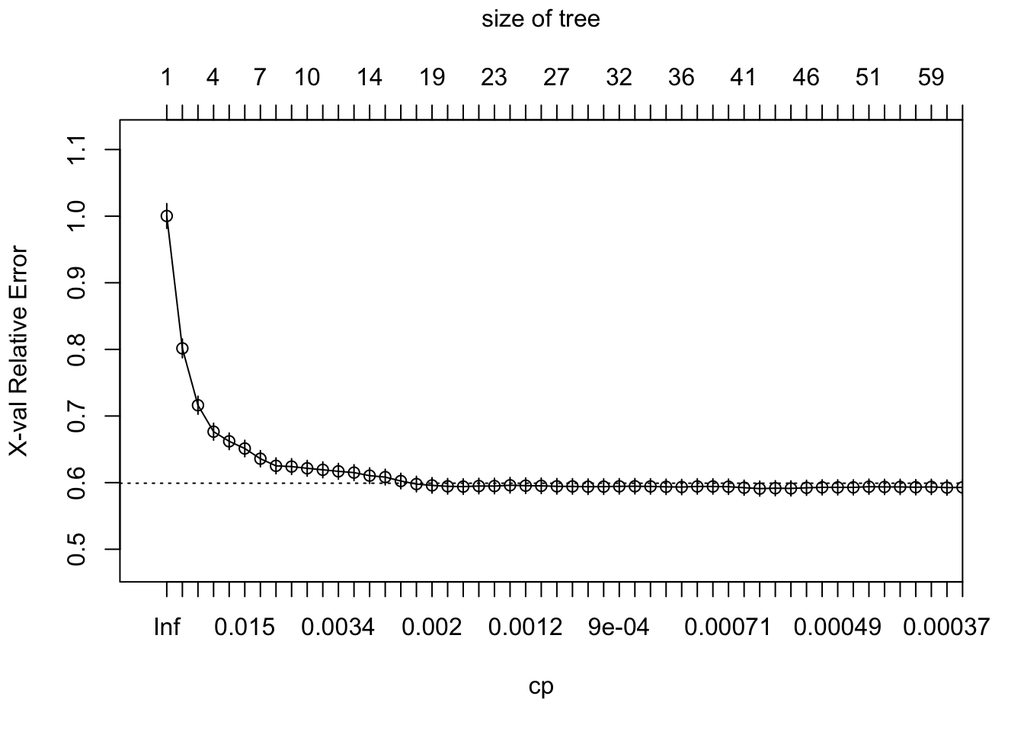

```r
rpart::plotcp(full_tree, xlim = c(0, 50))
```

Complexity parameters (printcp) are examined to prune the tree. The pruned tree reduces overfitting by focusing on the most critical splits.

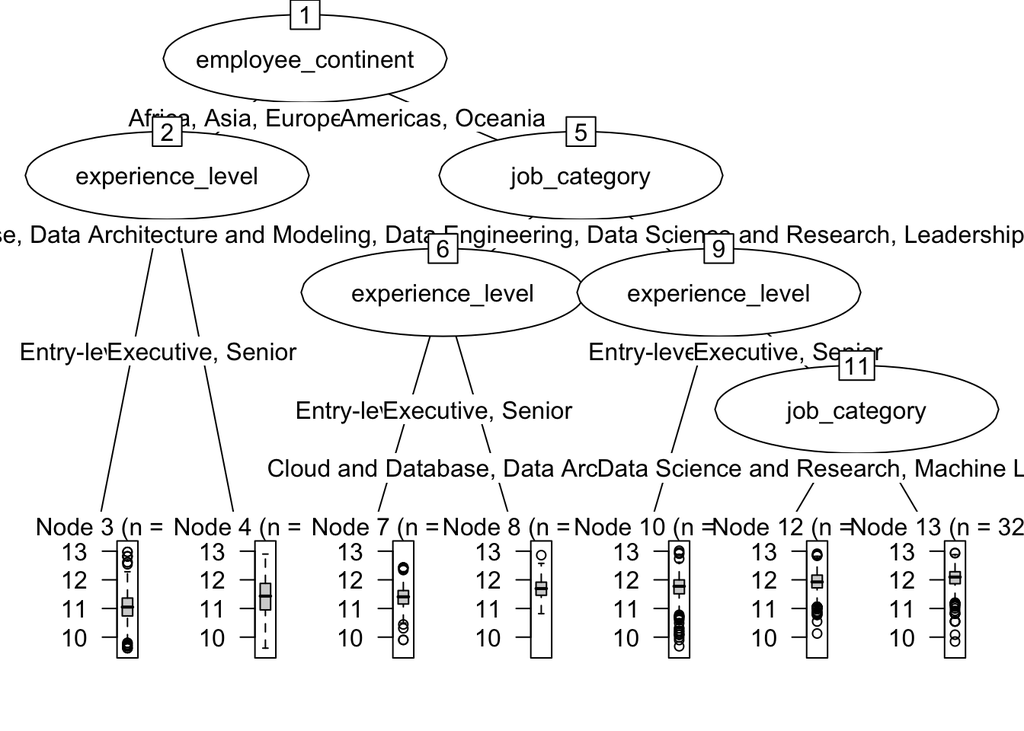

```r
pruned_tree <- prune(full_tree, cp = full_tree$cptable[7, "CP"])
plot(as.party(pruned_tree))
```

### Random Forest

A random forest model is trained using ranger with salary_in_usd as the target variable. Permutation-based variable importance is computed.

```r
rf <- ranger(salary_in_usd ~ ., data = data_jobs, probability = FALSE, importance = "permutation")
print(rf)
```

```
## Ranger result
##
## Call:
##  ranger(salary_in_usd ~ ., data = data_jobs, probability = FALSE,      importance = "permutation")
##
## Type:                             Regression
## Number of trees:                  500
## Sample size:                      9355
## Number of independent variables:  8
## Mtry:                             2
## Target node size:                 5
## Variable importance mode:         permutation
## Splitrule:                        variance
## OOB prediction error (MSE):       0.1310682
## R squared (OOB):                  0.4080324
```

The random forest regression model predicts salaries in USD based on eight variables from the dataset. Using 500 decision trees, the model captures complex relationships by averaging predictions across trees, which enhances reliability.

Looking at the variable importance:

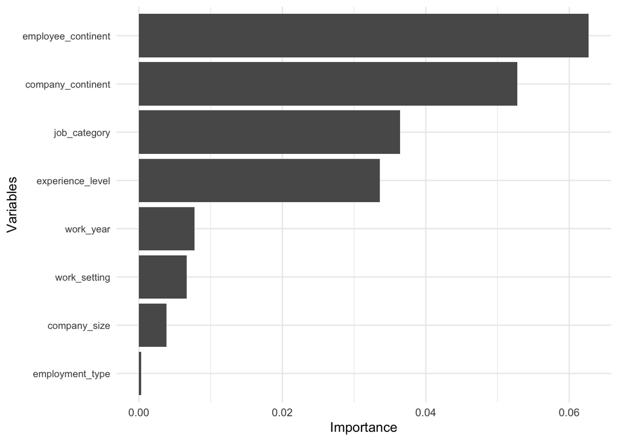

```r
importance_df <- data.frame(Variable = names(importance(rf)), Importance = importance(rf))

ggplot(importance_df, aes(x = reorder(Variable, Importance), y = Importance)) +
  geom_bar(stat = "identity") +
  coord_flip() +
  ylab("Importance") +
  xlab("Variables") +
  theme_minimal() +
  theme(axis.text.y = element_text(size = 8))
```

The model likely identifies variables like experience level, job category and company as well as employee continent as the most significant predictors.

### Cross-validation and comparison of the 3 models

```r
n <- nrow(data_jobs)
fold <- 10
set.seed(123)

folds <- sample(rep(1:fold, ceiling(n / fold)), n)
mse_results <- list()

for (tfold in seq_len(fold)) {
  train_idx <- which(folds != tfold)
  test_idx <- which(folds == tfold)

  rf_model <- ranger(salary_in_usd ~ ., data = data_jobs[train_idx, ])
  tree_model <- rpart(salary_in_usd ~ ., data = data_jobs[train_idx, ])
  prune(tree_model, cp = full_tree$cptable[7, "CP"])
  fitStepwise_model <- step(lm(salary_in_usd ~ ., data = data_jobs[train_idx, ]))

  p_rf <- predict(rf_model, data = data_jobs[test_idx, ])$predictions
  p_tr <- predict(tree_model, newdata = data_jobs[test_idx, ])
  p_lr <- predict(fitStepwise_model, newdata = data_jobs[test_idx, ])

  mse_results[[tfold]] <- unlist(lapply(
    list(rf = p_rf, tree = p_tr, lrm = p_lr),
    function(predicted) {
      mean((data_jobs[test_idx, "salary_in_usd"] - predicted)^2)
    }
  ))
}
```

```
## Start:  AIC=-17217.07
## salary_in_usd ~ work_year + job_category + experience_level +
##     employment_type + work_setting + company_size + employee_continent +
##     company_continent
##
##                      Df Sum of Sq    RSS    AIC
## <none>                            1082.1 -17217
## - company_continent   4     2.071 1084.2 -17209
## - employment_type     3     2.498 1084.6 -17204
## - work_setting        2     2.304 1084.4 -17203
## - company_size        2     2.632 1084.8 -17201
## - work_year           1     2.987 1085.1 -17196
## - employee_continent  4     9.837 1092.0 -17149
## - experience_level    3   143.372 1225.5 -16176
## - job_category        9   170.805 1252.9 -16001
## Start:  AIC=-17148.98
## salary_in_usd ~ work_year + job_category + experience_level +
##     employment_type + work_setting + company_size + employee_continent +
##     company_continent
##
##                      Df Sum of Sq    RSS    AIC
## <none>                            1090.5 -17149
## - employment_type     3     1.879 1092.4 -17140
## - work_setting        2     2.107 1092.6 -17137
## - company_size        2     2.592 1093.1 -17133
## - company_continent   4     3.453 1094.0 -17130
## - work_year           1     4.388 1094.9 -17117
## - employee_continent  4    11.538 1102.1 -17068
## - experience_level    3   134.096 1224.6 -16179
## - job_category        9   167.634 1258.2 -15963
## Start:  AIC=-17115.51
## salary_in_usd ~ work_year + job_category + experience_level +
##     employment_type + work_setting + company_size + employee_continent +
##     company_continent
##
##                      Df Sum of Sq    RSS    AIC
## <none>                            1094.9 -17116
## - employment_type     3     1.805 1096.7 -17108
## - company_continent   4     2.111 1097.0 -17107
## - work_setting        2     1.847 1096.7 -17105
```

[output cut: 95 more lines]

```
## Start:  AIC=-17071.48
## salary_in_usd ~ work_year + job_category + experience_level +
##     employment_type + work_setting + company_size + employee_continent +
##     company_continent
##
##                      Df Sum of Sq    RSS    AIC
## <none>                            1100.6 -17072
## - work_setting        2     1.839 1102.5 -17061
## - company_continent   4     2.871 1103.5 -17058
## - company_size        2     2.411 1103.0 -17057
## - employment_type     3     2.711 1103.3 -17057
## - work_year           1     4.559 1105.2 -17039
## - employee_continent  4    12.381 1113.0 -16985
## - experience_level    3   137.019 1237.6 -16090
## - job_category        9   166.814 1267.4 -15901
```

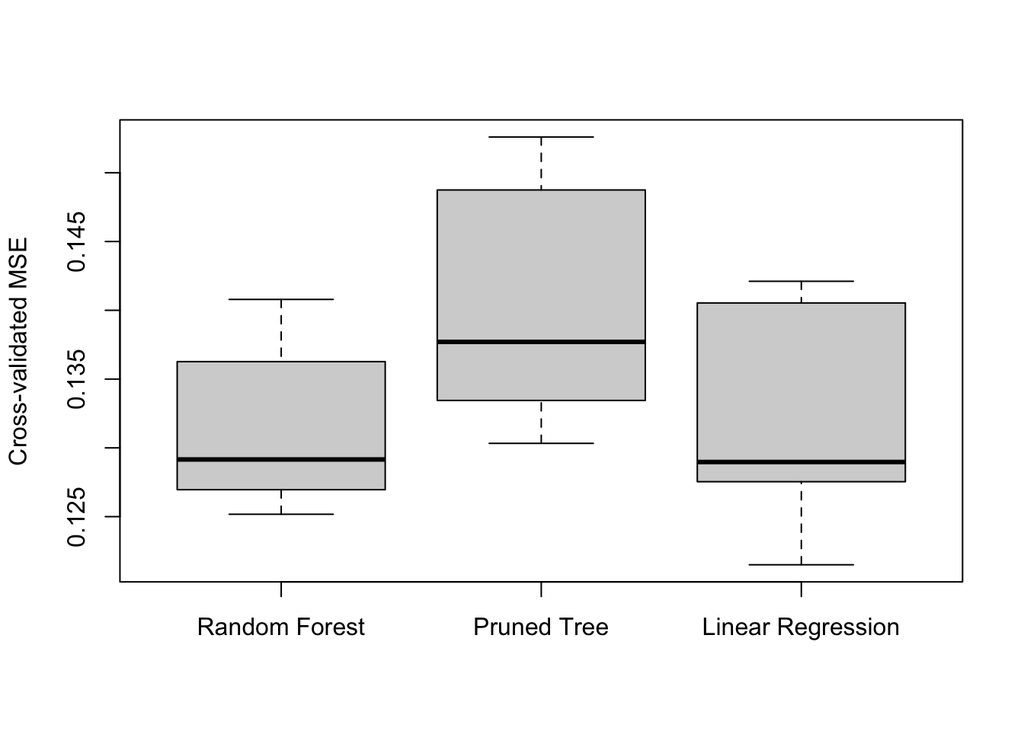

```r
mse_matrix <- do.call("rbind", mse_results)

boxplot(mse_matrix, names = c("Random Forest", "Pruned Tree", "Linear Regression"),
        ylab = "Cross-validated MSE")
```

The boxplot illustrates the cross-validated Mean Squared Error (MSE) for three models: Random Forest, Pruned Tree, and Linear Regression.

The Random Forest model shows the best performance, with the lowest median MSE and the smallest interquartile range (IQR), indicating that it makes the most accurate and consistent predictions. The Pruned Tree, on the other hand, has a higher MSE and a wider spread, which suggests that it is less accurate. Linear Regression performs almost as well as Random Forest, providing a similar level of accuracy and consistency.

## Classification

### Naive Bayes

The salary_in_usd variable is converted into a binary classification problem (“High” vs. “Low”) based on the median salary.

```r
data_jobs$salary_in_usd <- as.numeric(data_jobs$salary_in_usd)

median_salary <- median(data_jobs$salary_in_usd, na.rm = TRUE)
data_jobs$salary_in_usd <- as.factor(ifelse(data_jobs$salary_in_usd > median_salary, "High", "Low"))
```

The data is splitted into a training and a test data set. A Naive Bayes model is trained on predictors such as experience_level, company_size, and work_setting.

```r
set.seed(123)
trainIndex <- createDataPartition(data_jobs$salary_in_usd, p = 0.8, list = FALSE)
train_data <- data_jobs[trainIndex, ]
test_data <- data_jobs[-trainIndex, ]

model <- naiveBayes(salary_in_usd ~ experience_level + company_size + work_setting, data = train_data)

predictions <- predict(model, test_data)
```

Predictions are made on the test set, and the confusion matrix is computed using confusionMatrix(). Key metrics such as accuracy, precision, and recall are derived. Conditional probabilities for “High” salary predictions are analyzed, highlighting the influence of features.

```r
conf_matrix <- confusionMatrix(predictions, test_data$salary_in_usd)
print(conf_matrix)
```

```
## Confusion Matrix and Statistics
##
##           Reference
## Prediction High Low
##       High  816 544
##       Low   119 391
##
##                Accuracy : 0.6455
##                  95% CI : (0.6233, 0.6672)
##     No Information Rate : 0.5
##     P-Value [Acc > NIR] : < 2.2e-16
##
##                   Kappa : 0.2909
##
##  Mcnemar's Test P-Value : < 2.2e-16
##
##             Sensitivity : 0.8727
##             Specificity : 0.4182
##          Pos Pred Value : 0.6000
##          Neg Pred Value : 0.7667
##              Prevalence : 0.5000
##          Detection Rate : 0.4364
##    Detection Prevalence : 0.7273
##       Balanced Accuracy : 0.6455
##
##        'Positive' Class : High
##
```

```r
probabilities <- predict(model, test_data, type = "raw")

high_salary_probabilities <- probabilities[, "High"]

test_data$high_salary_probabilities <- high_salary_probabilities
```

The confusion matrix shows the performance of the classification model in predicting salary categories (High vs. Low). The model is correct 64.55% of the time. While decent, about 35% of predictions are incorrect. At 87.27%, the model is excellent at identifying High salaries, though some cases are still missed. At only 41.82%, the model struggles to identify Low salaries, often misclassifying them as High. When predicting High, it’s correct 60% of the time, meaning there are many false positives. Predictions for Low are more reliable, with a precision of 76.67%. The Kappa score of 0.29 indicates fair agreement between predictions and actual outcomes. Overall, the model is good at detecting High salaries but performs poorly on Low salaries.

## Visualizations

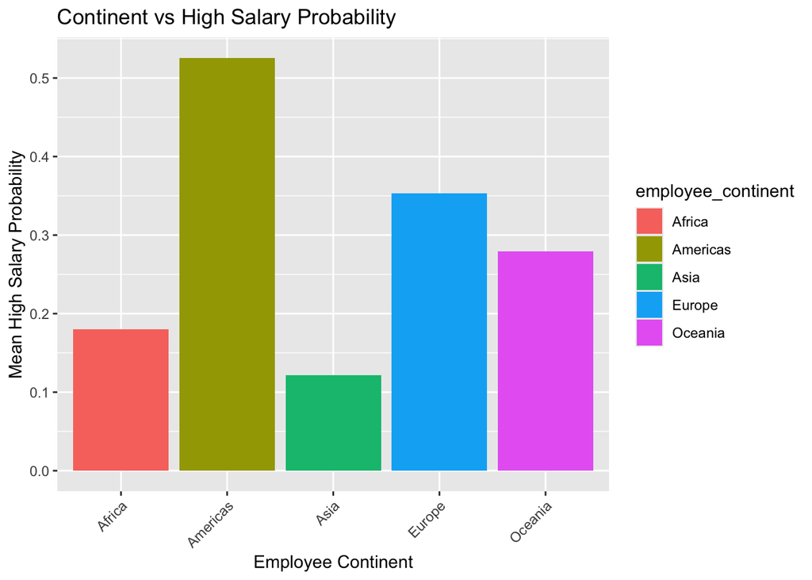

```r
ggplot(test_data, aes(x = employee_continent, y = high_salary_probabilities, fill = employee_continent)) +
  geom_bar(stat = "summary", fun = "mean", position = "dodge") +
  labs(
    title = "Continent vs High Salary Probability",
    x = "Employee Continent",
    y = "Mean High Salary Probability"
  ) +
  theme(axis.text.x = element_text(angle = 45, hjust = 1))
```

The visualization shows the relationship between employee continents and the mean probability of earning a high salary. Americas has the highest mean probability of high salaries, suggesting that employees from this region are most likely to earn higher salaries.

Europe and Oceania follow with moderate probabilities, indicating competitive but slightly lower high-salary chances compared to the America Asia has the lowest probability, suggesting fewer high salaries for employees in this region. Africa falls between Asia and Europe, with a relatively lower likelihood of high salaries. This suggests regional differences in salary distribution, potentially influenced by factors like industry, demand or cost of living.

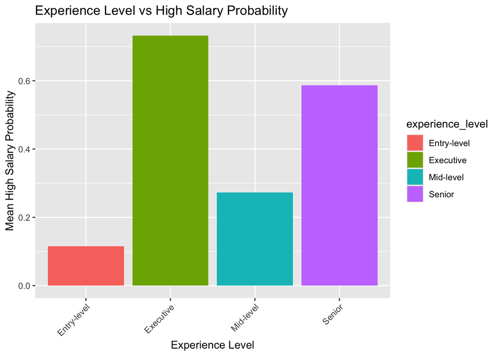

```r
ggplot(test_data, aes(x = experience_level, y = high_salary_probabilities, fill = experience_level)) +
  geom_bar(stat = "summary", fun = "mean", position = "dodge") +
  labs(title = "Experience Level vs High Salary Probability", x = "Experience Level", y = "Mean High Salary Probability") +
  theme(axis.text.x = element_text(angle = 45, hjust = 1))
```

This visualization examines the relationship between experience levels and the mean probability of earning a high salary. Executives show the highest mean probability of earning high salaries, emphasizing the strong correlation between leadership roles and higher compensation. Senior-level employees also have a high probability, though slightly less than executives, reflecting their advanced skills and experience. Mid-level professionals have a moderate probability, indicating growth potential but still not as competitive as higher levels. Entry-level employees have the lowest probability of high salaries, reflecting the typical compensation at the start of a career. The trend highlights that salary expectations increase significantly with higher levels of experience and leadership roles.

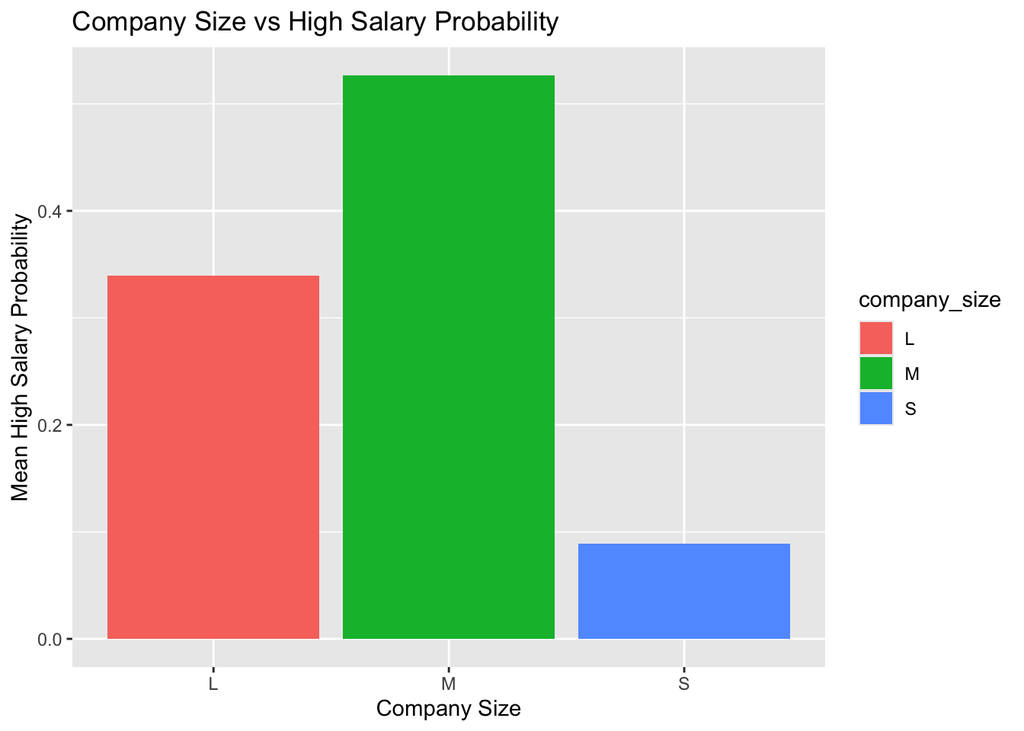

```r
ggplot(test_data, aes(x = company_size, y = high_salary_probabilities, fill = company_size)) +
  geom_bar(stat = "summary", fun = "mean", position = "dodge") +
  labs(title = "Company Size vs High Salary Probability", x = "Company Size", y = "Mean High Salary Probability")
```

This visualization highlights the relationship between company size and the mean probability of earning a high salary. Medium-sized companies exhibit the highest probability of high salaries, suggesting a competitive balance between resources and the ability to attract and retain talent. Large companies have a moderate probability, reflecting stable pay structures but potentially less individual salary growth compared to medium-sized firms. Small companies show the lowest probability, likely due to limited financial resources and budget constraints for high salaries. This pattern suggests that medium-sized companies might strike the optimal balance for offering higher compensation.

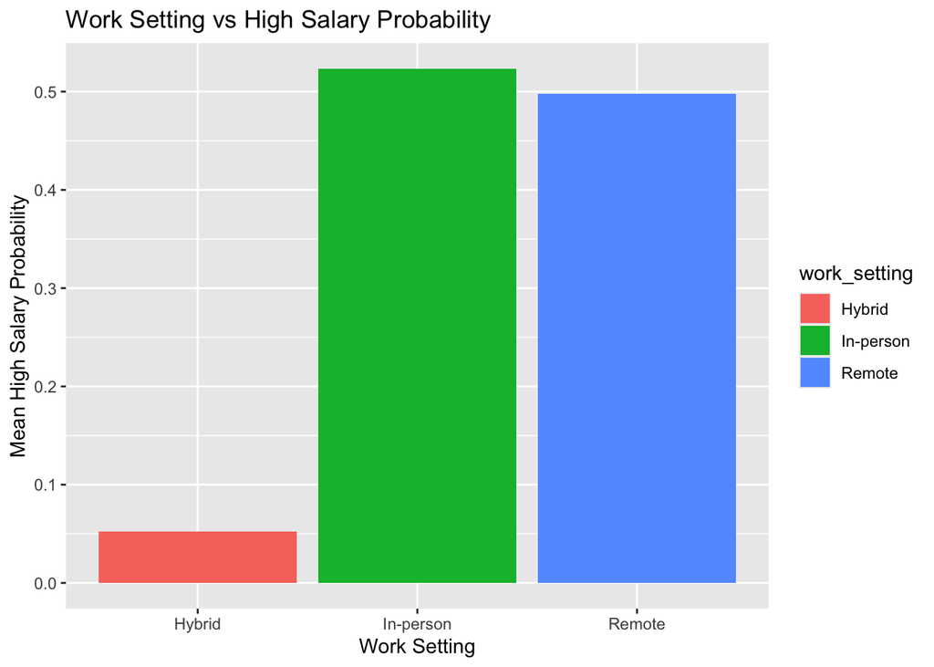

```r
ggplot(test_data, aes(x = work_setting, y = high_salary_probabilities, fill = work_setting)) +
  geom_bar(stat = "summary", fun = "mean", position = "dodge") +
  labs(title = "Work Setting vs High Salary Probability", x = "Work Setting", y = "Mean High Salary Probability")
```

This visualization examines the impact of different work settings on the probability of earning a high salary. In-person settings show the highest mean probability of high salaries, indicating a preference for physically present employees in roles offering higher compensation. Remote settings closely follow in-person roles, reflecting the growing acceptance and competitiveness of remote work for high-paying positions. Hybrid work settings, however, show the lowest probability of high salaries, possibly indicating less emphasis on such roles for high-paying opportunities. The results suggest that companies may still value physical or entirely remote presence over hybrid arrangements when offering higher salaries.

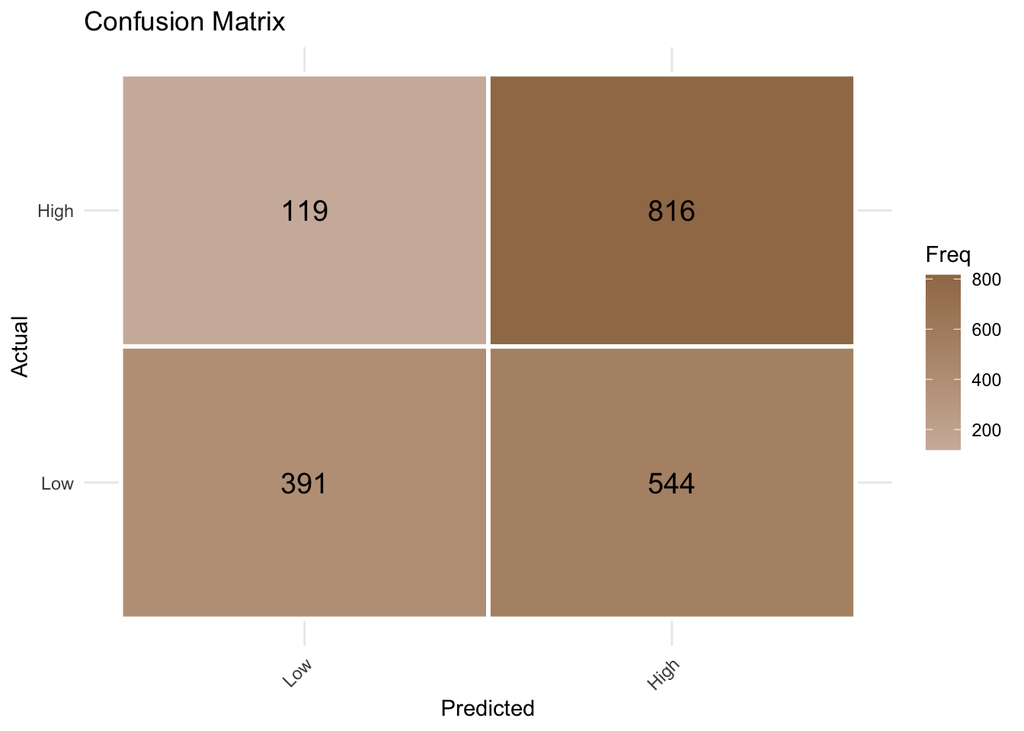

```r
conf_matrix_df <- as.data.frame(conf_matrix$table)

ggplot(conf_matrix_df, aes(x = Prediction, y = Reference, fill = Freq)) +
  geom_tile(color = "white", linewidth = 1) +  # Creates the tiles
  scale_fill_gradient(low = "#D0B8A8", high = "#A07A56") +  # Low = light yellow, high = dark green
  geom_text(aes(label = Freq), color = "black", size = 5) +  # Display numbers on the tiles
  labs(title = "Confusion Matrix", x = "Predicted", y = "Actual") +
  theme_minimal() +
  theme(axis.text.x = element_text(angle = 45, hjust = 1),  # Rotate x-axis labels
        axis.text.y = element_text(angle = 0, hjust = 1)) +  # Ensure y-axis labels are clear
  scale_y_discrete(limits = rev(levels(conf_matrix_df$Reference))) +  # Invert Y-axis
  scale_x_discrete(limits = rev(levels(conf_matrix_df$Prediction)))
```

## Conclusion

This project analyzed factors influencing salaries in the data job market, comparing regression models and Naive Bayes classification. While regression analyses, such as linear regression and random forests, offered insights into how predictors influence salary, their R-squared values indicated relatively low explanatory power, limiting their accuracy.